# Final Exam Time Series Fall 2019 (Take Home)

```r
#stationary
ss1.est.y = est.arma.wge(sunspot1$x, p = 3, q = 2)
```

```
##
## Coefficients of Original polynomial:
## 2.2526 -1.5425 0.2879
##
## Factor                 Roots                Abs Recip    System Freq
## 1-1.9507B+0.9536B^2    1.0228+-0.0498i      0.9765       0.0077
## 1-0.3019B              3.3125               0.3019       0.0000
##
##
```

Once the model is deverloped, we want to check the residuals to ensure the model has been fitted properly. We can check the residuals by looking at the ACF and the Ljung-Box Test to determine if the null hypothesis is rejected.

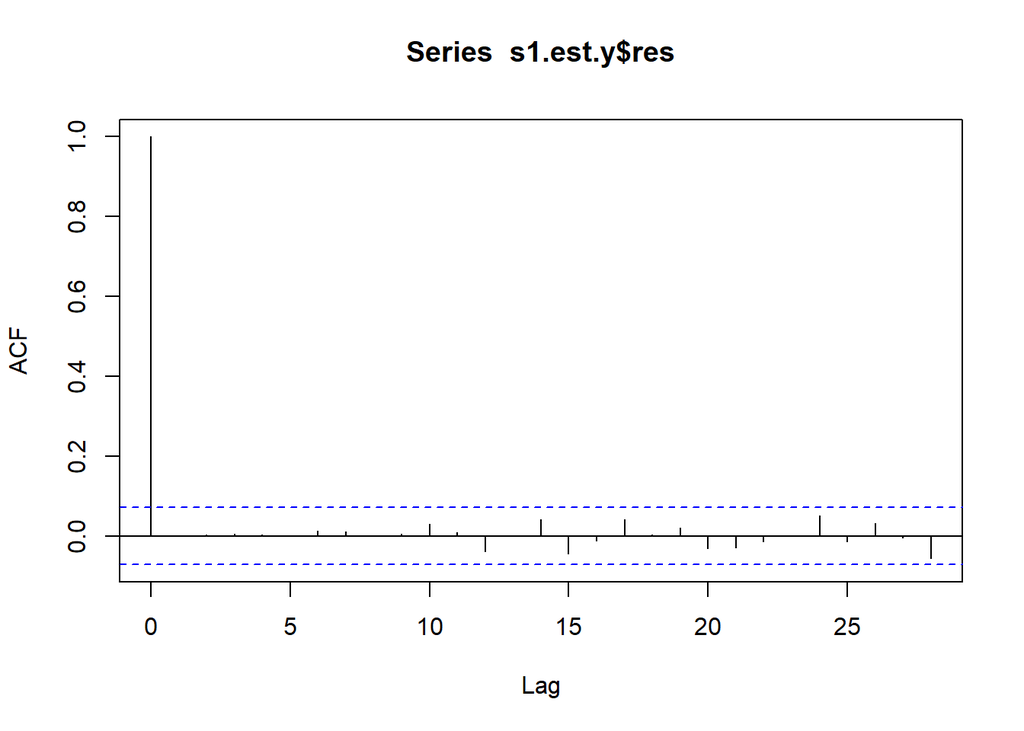

```r
# Non-stationary
# Verify residuals are white noise
acf(s1.est.y$res)
```

```r
# Ljung-Box test, K = 24 (default)
ljung.wge(s1.est.y$res)$pval
```

```
## Obs 0.0001777755 0.002657331 0.006307208 0.002829306 0.002264481 0.01295824 0.010508 0.001488446 0.005343139 0.03009024 0.008677143 -0.03912587 0.002182461 0.04086041 -0.04358327 -0.01219509 0.0421845 0.003480701 0.02004524 -0.03072301 -0.02910507 -0.0131232 0.0006392228 0.05074535
```

```
## [1] 0.9929308
```

```r
#Ljung-Box test, K = 48
ljung.wge(s1.est.y$res, K = 48)$pval
```

```
## Obs 0.0001777755 0.002657331 0.006307208 0.002829306 0.002264481 0.01295824 0.010508 0.001488446 0.005343139 0.03009024 0.008677143 -0.03912587 0.002182461 0.04086041 -0.04358327 -0.01219509 0.0421845 0.003480701 0.02004524 -0.03072301 -0.02910507 -0.0131232 0.0006392228 0.05074535 -0.01376697 0.…
```

```
## [1] 0.9444058
```

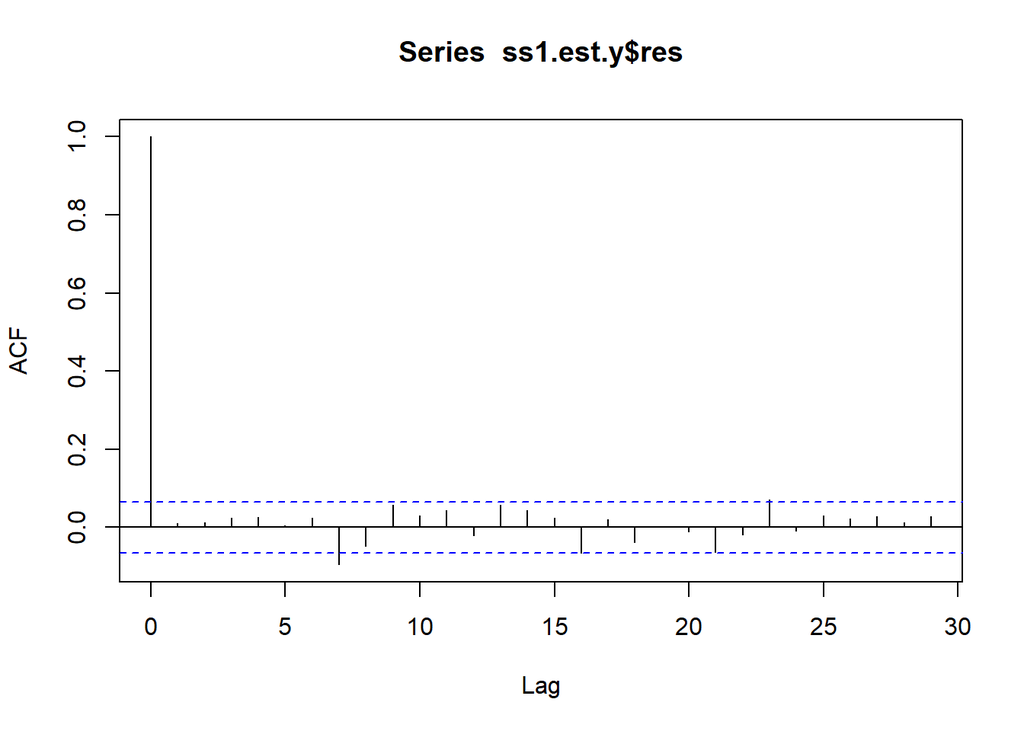

```r
# Stationary
# Verify residuals are white noise
acf(ss1.est.y$res)
```

```r
# Ljung-Box test, K = 24 (default)
ljung.wge(ss1.est.y$res)$pval
```

```
## Obs 0.009640221 0.01190994 0.02490855 0.02524979 0.004487394 0.02474641 -0.09524703 -0.04812243 0.05737002 0.03066198 0.04393751 -0.02056999 0.05718796 0.04372878 0.02466942 -0.06466976 0.01955491 -0.03784132 0.003014428 -0.01092519 -0.06405102 -0.01897771 0.0709513 -0.009280094
```

```
## [1] 0.03402462
```

```r
#Ljung-Box test, K = 48
ljung.wge(ss1.est.y$res, K = 48)$pval
```

```
## Obs 0.009640221 0.01190994 0.02490855 0.02524979 0.004487394 0.02474641 -0.09524703 -0.04812243 0.05737002 0.03066198 0.04393751 -0.02056999 0.05718796 0.04372878 0.02466942 -0.06466976 0.01955491 -0.03784132 0.003014428 -0.01092519 -0.06405102 -0.01897771 0.0709513 -0.009280094 0.02933314 0.0219…
```

```
## [1] 0.1930752
```

```r
# ASE - Non-stationary
s1.fit = fore.aruma.wge(sunspot1$x, s = 143, phi = s1.est.y$phi, theta = s1.est.y$theta, n.ahead = 120, limits = FALSE, lastn = TRUE)
```

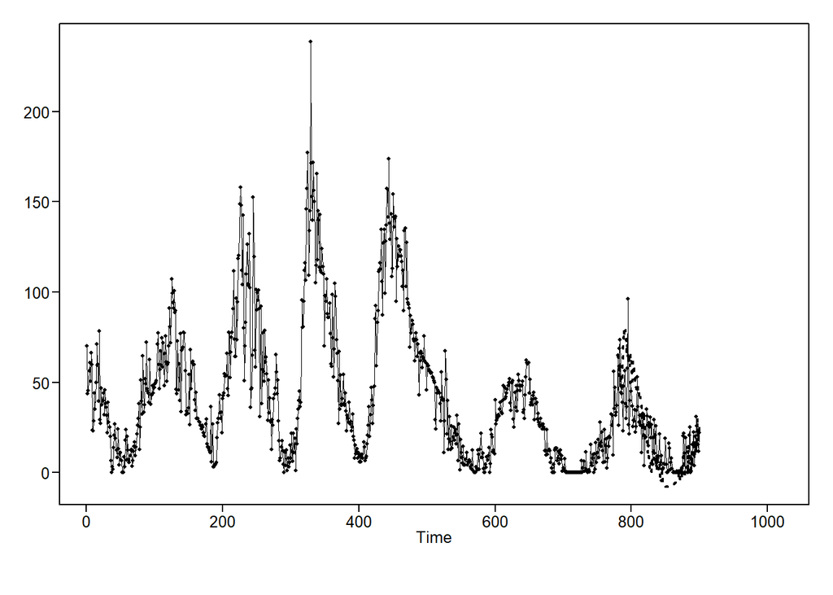

```r
ASE1 = mean((sunspot1$x[781:900] - s1.fit$f)^2)
ASE1
```

```
## [1] 284.6697
```

```r
# ASE - Stationary
ss1.fit = fore.aruma.wge(sunspot1$x, phi = ss1.est.y$phi, theta = ss1.est.y$theta, n.ahead = 120, limits = FALSE, lastn = TRUE)
```

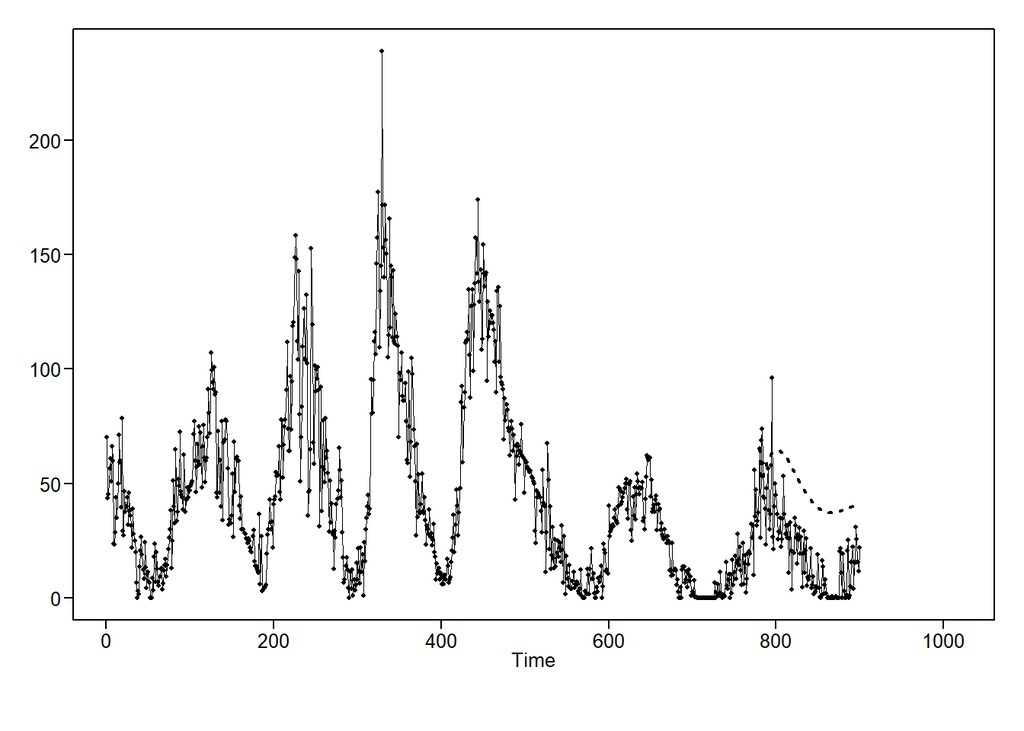

```r
ASE1s = mean((sunspot1$x[781:900] - ss1.fit$f)^2)
ASE1s
```

```
## [1] 972.5727
```

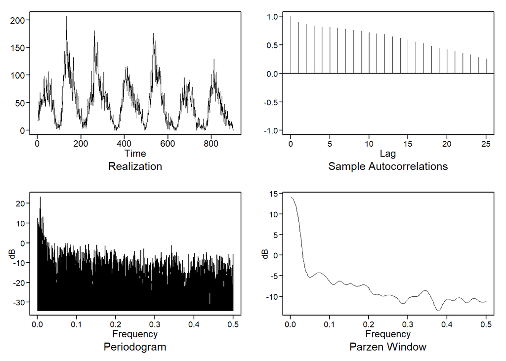

[output not shown]

[output cut: 266 more lines]

```r
# subset 2
sunspot2 = subset(sunspot, Date > as.Date('1825-12-01') & Date < as.Date('1901-01-01'))

plotts.sample.wge(sunspot2$x) #frequency near 0; = 0.007
```

```r
# remove the (1-B)^143 (seasonality)
s2 = artrans.wge(sunspot2$x, phi.tr = c(rep(0,142),1))
```

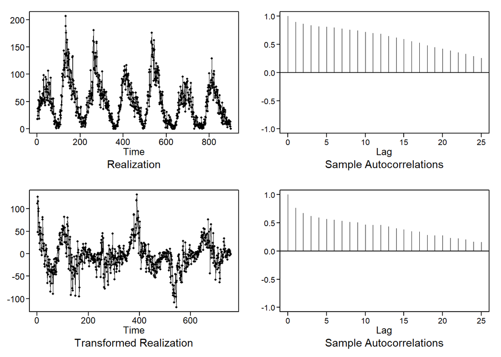

```r
s2m1 = aic.wge(s2, p = 0:10, q = 0:10) # picks ARMA(8,5)
s2m2 = aic.wge(s2,p = 0:10, q = 0:10, type = "bic") # picks ARMA(2,1)

paste0('AIC Recommends: ARMA(',s2m1$p,',',s2m1$q,'); w/ Variance:',s2m1$vara)
```

```
## [1] "AIC Recommends: ARMA(8,5); w/ Variance:396.489243505004"
```

```r
paste0('BIC Recommends: ARMA(',s2m2$p,',',s2m2$q,'); w/ Variance:',s2m2$vara)
```

```
## [1] "BIC Recommends: ARMA(2,1); w/ Variance:413.27698191066"
```

```r
ss2m1 = aic.wge(sunspot2$x) # picks ARMA(2,1)
ss2m2 = aic.wge(sunspot2$x, type = "bic") # picks ARMA(2,1)

print('Stationary Model')
```

```
## [1] "Stationary Model"
```

```r
paste0('AIC Recommends: ARMA(',ss2m1$p,',',ss2m1$q,'); w/ Variance:',ss2m1$vara)
```

```
## [1] "AIC Recommends: ARMA(2,1); w/ Variance:237.283614809639"
```

```r
paste0('BIC Recommends: ARMA(',ss2m2$p,',',ss2m2$q,'); w/ Variance:',ss2m2$vara)
```

```
## [1] "BIC Recommends: ARMA(2,1); w/ Variance:237.283614809639"
```

```r
# Store model estimation
# Non-stationary
s2.est.y = est.arma.wge(s2, p = 2, q = 1)
```

```
##
## Coefficients of Original polynomial:
## 1.2740 -0.2934
##
## Factor                 Roots                Abs Recip    System Freq
## 1-0.9722B              1.0286               0.9722       0.0000
## 1-0.3018B              3.3137               0.3018       0.0000
##
##
```

```r
# Stationary
ss2.est.y = est.arma.wge(sunspot2$x, p = 2, q = 1)
```

```
##
## Coefficients of Original polynomial:
## 1.1917 -0.2077
##
## Factor                 Roots                Abs Recip    System Freq
## 1-0.9797B              1.0207               0.9797       0.0000
## 1-0.2120B              4.7169               0.2120       0.0000
##
##
```

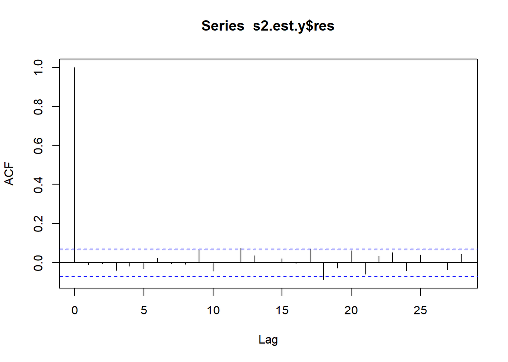

```r
# Non-stationary
# Verify is residuals are white noise
acf(s2.est.y$res)
```

```r
# Ljung-Box test, K = 24 (default)
ljung.wge(s2.est.y$res)$pval
```

```
## Obs -0.009920755 -0.004420483 -0.03809176 -0.0176219 -0.0311761 0.02573317 -0.006655321 -0.00799827 0.06799068 -0.04247904 0.0008573719 0.07470319 0.0381565 0.0001352001 0.02219571 -0.005087474 0.07336314 -0.08557682 -0.02742279 0.06282334 -0.05801505 0.03686053 0.05346446 -0.04158162
```

```
## [1] 0.07861718
```

```r
#Ljung-Box test, K = 48
ljung.wge(s2.est.y$res, K = 48)$pval
```

```
## Obs -0.009920755 -0.004420483 -0.03809176 -0.0176219 -0.0311761 0.02573317 -0.006655321 -0.00799827 0.06799068 -0.04247904 0.0008573719 0.07470319 0.0381565 0.0001352001 0.02219571 -0.005087474 0.07336314 -0.08557682 -0.02742279 0.06282334 -0.05801505 0.03686053 0.05346446 -0.04158162 0.04233433 …
```

```
## [1] 0.0325282
```

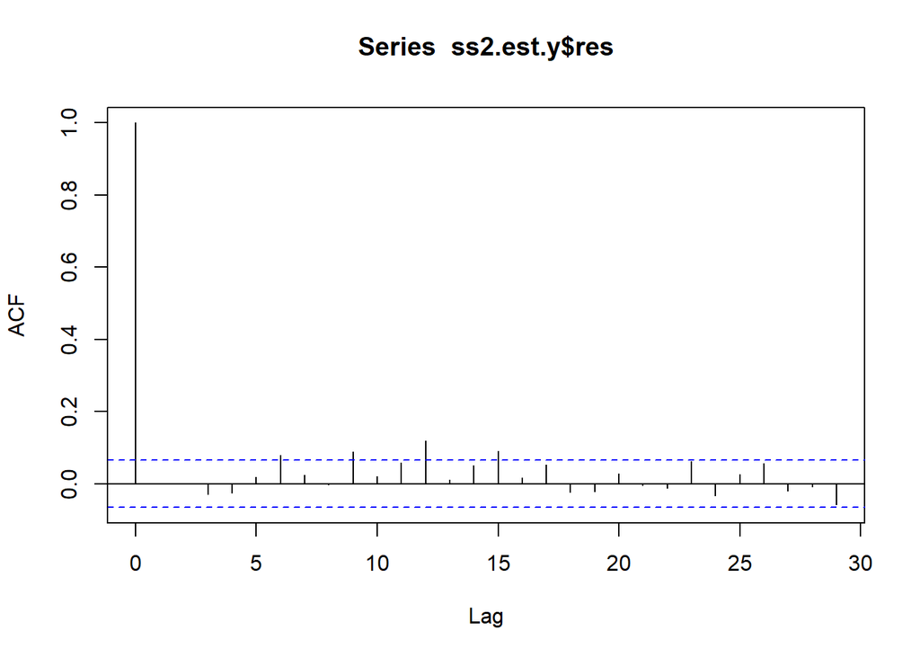

```r
# Stationary
# Verify is residuals are white noise
acf(ss2.est.y$res)
```

```r
# Ljung-Box test, K = 24 (default)
ljung.wge(ss2.est.y$res)$pval
```

```
## Obs 0.001152942 0.0002770792 -0.02825333 -0.02492409 0.01887187 0.07996714 0.02372532 -0.001906439 0.0891138 0.01974918 0.05897311 0.1197658 0.0106676 0.05065788 0.0900219 0.01614604 0.05271026 -0.02286504 -0.02106203 0.02790125 -0.004257077 -0.01258173 0.0620354 -0.03336677
```

```
## [1] 0.001099337
```

```r
#Ljung-Box test, K = 48
ljung.wge(ss2.est.y$res, K = 48)$pval
```

```
## Obs 0.001152942 0.0002770792 -0.02825333 -0.02492409 0.01887187 0.07996714 0.02372532 -0.001906439 0.0891138 0.01974918 0.05897311 0.1197658 0.0106676 0.05065788 0.0900219 0.01614604 0.05271026 -0.02286504 -0.02106203 0.02790125 -0.004257077 -0.01258173 0.0620354 -0.03336677 0.02592025 0.0559865 …
```

```
## [1] 0.0004679938
```

```r
# ASE
s2.fit = fore.aruma.wge(sunspot2$x, s = 143, phi = s2.est.y$phi, theta = s2.est.y$theta, n.ahead = 120, limits = FALSE, lastn = TRUE)
```

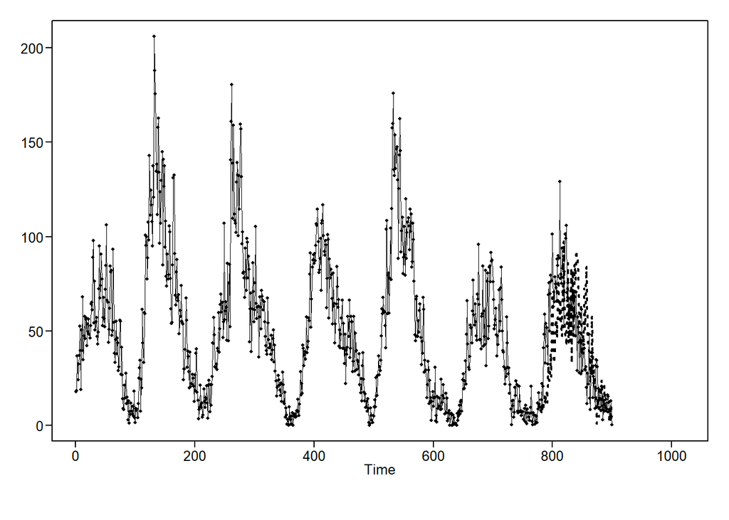

```r
ASE2 = mean((sunspot2$x[781:900] - s2.fit$f)^2)
ASE2
```

```
## [1] 678.4167
```

```r
ss2.fit = fore.aruma.wge(sunspot2$x, phi = ss2.est.y$phi, theta = ss2.est.y$theta, n.ahead = 120, limits = FALSE, lastn = TRUE)
```

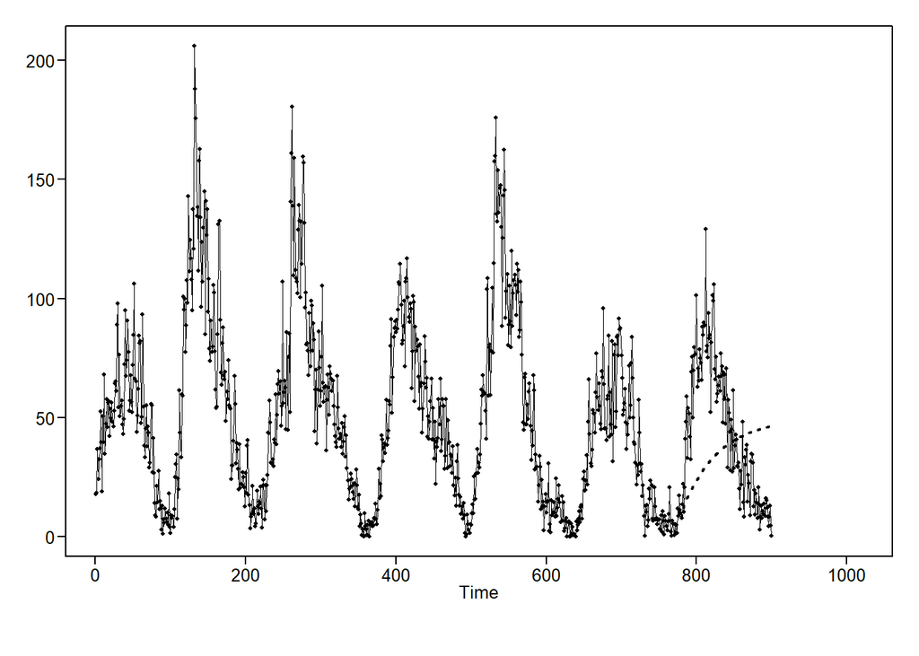

```r
ASE2s = mean((sunspot2$x[781:900] - ss2.fit$f)^2)
ASE2s
```

```
## [1] 1314.86
```

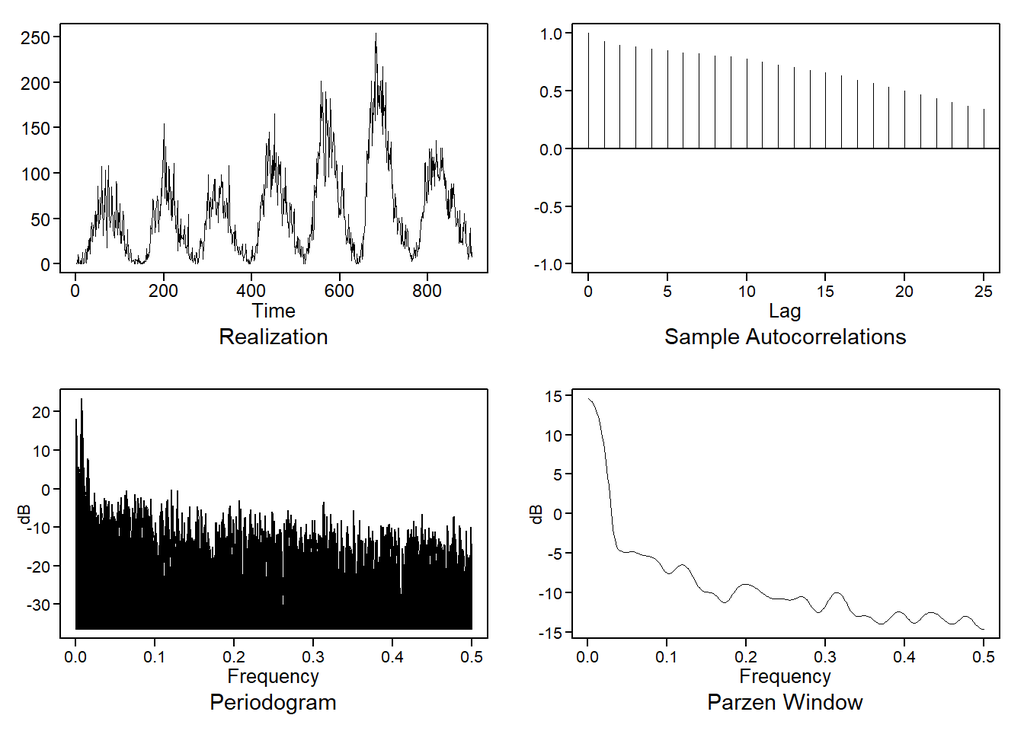

[output not shown]

[output cut: 266 more lines]

```r
# subset 3
sunspot3 = subset(sunspot, Date > as.Date('1900-12-01') & Date < as.Date('1976-01-01'))

plotts.sample.wge(sunspot3$x) #frequency near 0; = 0.007
```

```r
# remove the (1-B)^143 (seasonality)
s3 = artrans.wge(sunspot3$x, phi.tr = c(rep(0,142),1))
```

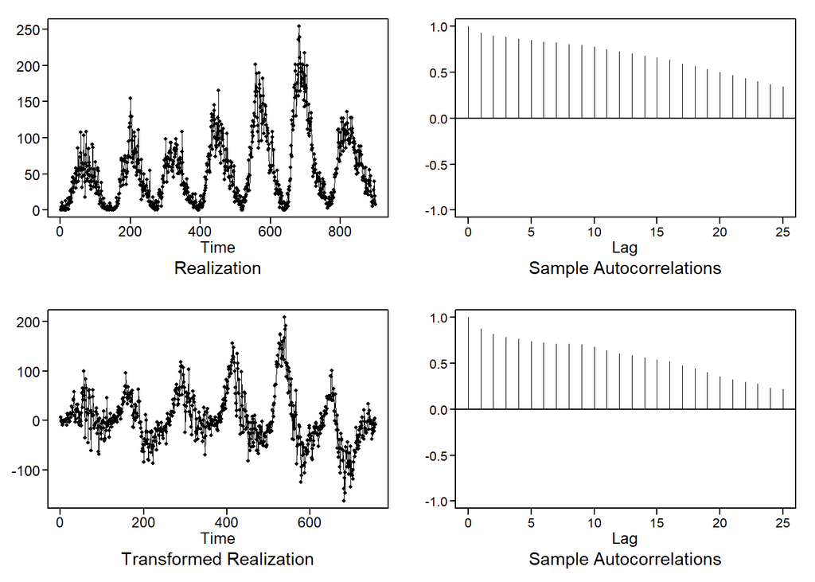

```r
# Non-stationary
s3m1 = aic.wge(s3, p = 0:10, q = 0:10) # picks ARMA(9,8)
s3m2 = aic.wge(s3,p = 0:10, q = 0:10, type = "bic") # picks ARMA(1,2)

paste0('AIC Recommends: ARMA(',s3m1$p,',',s3m1$q,'); w/ Variance:',s3m1$vara)
```

```
## [1] "AIC Recommends: ARMA(9,8); w/ Variance:526.041452329412"
```

```r
paste0('BIC Recommends: ARMA(',s3m2$p,',',s3m2$q,'); w/ Variance:',s3m2$vara)
```

```
## [1] "BIC Recommends: ARMA(1,2); w/ Variance:573.615106366589"
```

```r
# Stationary
ss3m1 = aic.wge(sunspot3$x, p = 0:10, q = 0:10) # picks ARMA(9,8)
ss3m2 = aic.wge(sunspot3$x,p = 0:10, q = 0:10, type = "bic") # picks ARMA(9,8)

paste0('AIC Recommends: ARMA(',ss3m1$p,',',ss3m1$q,'); w/ Variance:',ss3m1$vara)
```

```
## [1] "AIC Recommends: ARMA(9,8); w/ Variance:237.732019010644"
```

```r
paste0('BIC Recommends: ARMA(',ss3m2$p,',',ss3m2$q,'); w/ Variance:',ss3m2$vara)
```

```
## [1] "BIC Recommends: ARMA(9,8); w/ Variance:237.732019010644"
```

```r
# Store model estimation
s3.est.y = est.arma.wge(s3, p = 9, q = 8)
```

```
##
## Coefficients of Original polynomial:
## 1.1602 -0.2139 0.4417 -1.0125 0.7541 -0.0447 0.6578 -1.1956 0.4284
##
## Factor                 Roots                Abs Recip    System Freq
## 1+0.7660B+0.9999B^2   -0.3830+-0.9238i      0.9999       0.3126
## 1+1.6586B+0.9700B^2   -0.8550+-0.5477i      0.9849       0.4093
## 1-1.1906B+0.9544B^2    0.6237+-0.8116i      0.9769       0.1457
## 1-1.8609B+0.8677B^2    1.0723+-0.0518i      0.9315       0.0077
## 1-0.5333B              1.8750               0.5333       0.0000
##
##
```

```r
ss3.est.y = est.arma.wge(sunspot3$x, p = 9, q = 8)
```

```
##
## Coefficients of Original polynomial:
## 0.7883 0.2447 0.0455 -0.0008 0.1105 0.2546 0.1473 -1.0982 0.4905
##
## Factor                 Roots                Abs Recip    System Freq
## 1+0.7657B+0.9981B^2   -0.3836+-0.9245i      0.9991       0.3126
## 1+1.8476B+0.9972B^2   -0.9264+-0.3803i      0.9986       0.4380
## 1-1.9580B+0.9614B^2    1.0183+-0.0562i      0.9805       0.0088
## 1-0.9102B+0.9612B^2    0.4735+-0.9034i      0.9804       0.1732
## 1-0.5333B              1.8751               0.5333       0.0000
##
##
```

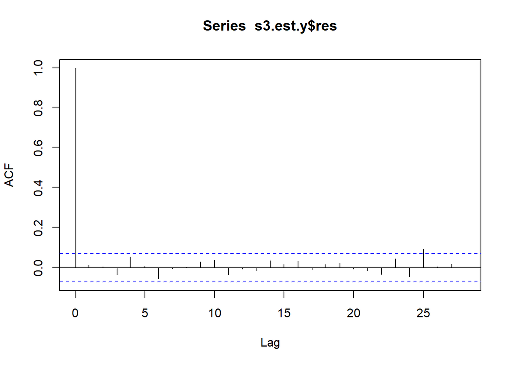

```r
# Non-stationary
# Verify is residuals are white noise
acf(s3.est.y$res)
```

```r
# Ljung-Box test, K = 24 (default)
ljung.wge(s3.est.y$res)$pval
```

```
## Obs 0.01341179 0.004736403 -0.03537523 0.05528547 0.008100624 -0.05402257 -0.003546306 0.004267348 0.03039659 0.03826974 -0.03551574 -0.006882257 -0.01489705 0.03576005 0.01684666 0.03466512 -0.008737775 0.01738892 0.02222974 -0.005929137 -0.01484407 -0.03285187 0.04511355 -0.04501838
```

```
## [1] 0.8949489
```

```r
#Ljung-Box test, K = 48
ljung.wge(s3.est.y$res, K = 48)$pval
```

```
## Obs 0.01341179 0.004736403 -0.03537523 0.05528547 0.008100624 -0.05402257 -0.003546306 0.004267348 0.03039659 0.03826974 -0.03551574 -0.006882257 -0.01489705 0.03576005 0.01684666 0.03466512 -0.008737775 0.01738892 0.02222974 -0.005929137 -0.01484407 -0.03285187 0.04511355 -0.04501838 0.09285306 …
```

```
## [1] 0.3663408
```

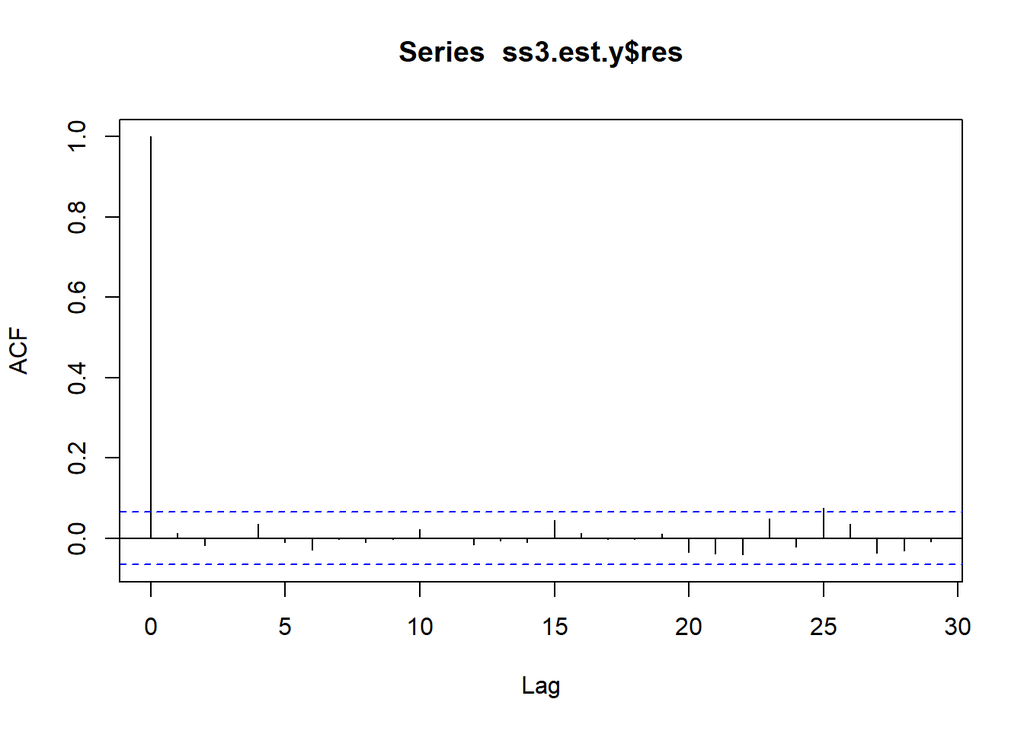

```r
# Stationary
# Verify is residuals are white noise
acf(ss3.est.y$res)
```

```r
# Ljung-Box test, K = 24 (default)
ljung.wge(ss3.est.y$res)$pval
```

```
## Obs 0.01221698 -0.01776499 -0.000302198 0.03493136 -0.009059522 -0.02869283 -0.002757574 -0.009087895 -0.001446877 0.02301425 -0.0007336579 -0.01480572 -0.007102735 -0.009981644 0.04459079 0.01312964 -0.001774123 -0.001931526 0.01087477 -0.03514714 -0.03801659 -0.04051899 0.04849871 -0.02081719
```

```
## [1] 0.9807739
```

```r
#Ljung-Box test, K = 48
ljung.wge(ss3.est.y$res, K = 48)$pval
```

```
## Obs 0.01221698 -0.01776499 -0.000302198 0.03493136 -0.009059522 -0.02869283 -0.002757574 -0.009087895 -0.001446877 0.02301425 -0.0007336579 -0.01480572 -0.007102735 -0.009981644 0.04459079 0.01312964 -0.001774123 -0.001931526 0.01087477 -0.03514714 -0.03801659 -0.04051899 0.04849871 -0.02081719 0…
```

```
## [1] 0.8848648
```

```r
# ASE
# Non-stationary
s3.fit = fore.aruma.wge(sunspot3$x, s = 143, phi = s3.est.y$phi, theta = s3.est.y$theta, n.ahead = 120, limits = FALSE, lastn = TRUE)
```

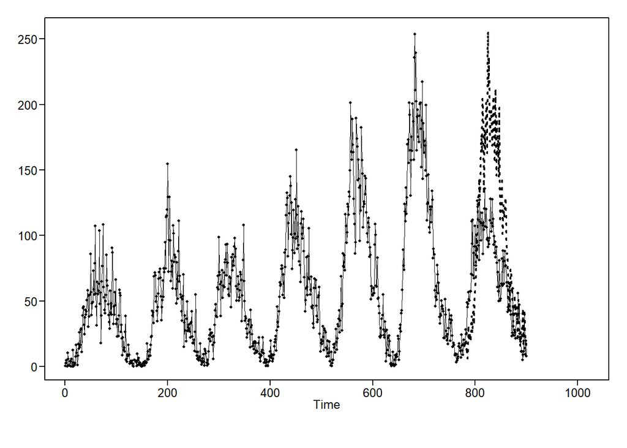

```r
ASE3 = mean((sunspot3$x[781:900] - s3.fit$f)^2)
ASE3
```

```
## [1] 3433.282
```

```r
# Stationary
ss3.fit = fore.aruma.wge(sunspot3$x, phi = ss3.est.y$phi, theta = ss3.est.y$theta, n.ahead = 120, limits = FALSE, lastn = TRUE)
```

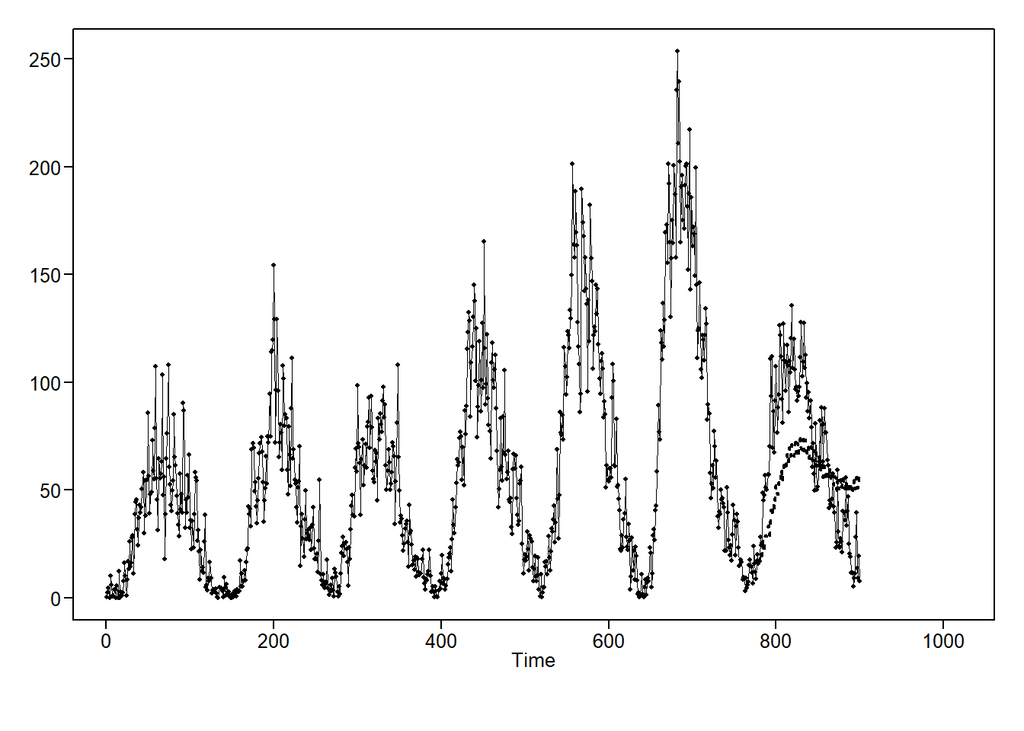

```r
ASE3s = mean((sunspot3$x[781:900] - ss3.fit$f)^2)
ASE3s
```

```
## [1] 1096.614
```

```r
(ASE1 + ASE2 + ASE3)/3
```

```
## [1] 1465.456
```

```r
(ASE1s + ASE2s + ASE3s)/3
```

```
## [1] 1128.015
```

Comparing both stationary and non-stationary models, we found the stationary models performed better than the stationary models. They were more useful in predicting the values moving forward and have lower ASE values. While it appeared (visually) that the non-stationary models were better at predicting the values, the fact that they were repeating the last iteration was penalizaing them.  
Looking at the complete data, it appears there are high peaks and low peaks. However, the non-stationary assumes these are following some cycle, while the stationary model fails to account for them. This allows the stationary model to use the sample mean in order to produce values moving forward instead of the last iteration, such as the non-stationary model. **3. Based on your findings and your intuition, fit a stationary or non-stationary model to each partition and use it to forecast the last 12 months of that partition (you may refit the model for each partition or use the same model… your choice). Calculate and report the ASE of each forecast and compare it to the ASE from the RNN model. Also, fully specify your model(s) in backshift notation.**

```r
# model 1
# ARIMA(3,2)
s1.fit12 = fore.arma.wge(sunspot1$x, phi = ss1.est.y$phi, theta = ss1.est.y$theta, n.ahead = 12, limits = FALSE, lastn = TRUE)
```

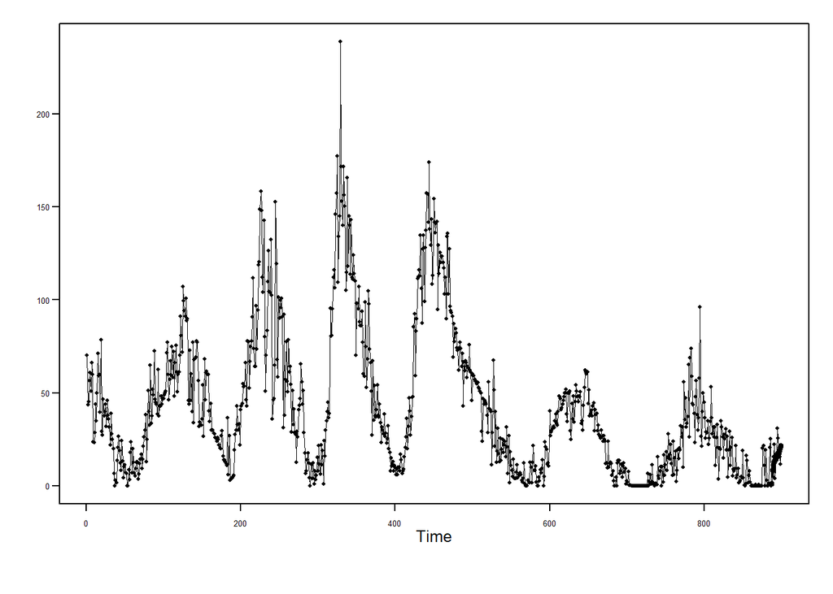

```r
# ASE
mean((sunspot1$x[889:900] - s1.fit12$f)^2)
```

```
## [1] 50.37976
```

```r
# RNN
rnns1 = ts(sunspot1$x[1:888])
rnns1.fit = mlp(rnns1)
f1 = forecast(rnns1.fit, h = 12)

# ASE
mean((sunspot1$x[889:900]-f1$mean)^2)
```

```
## [1] 115.6281
```

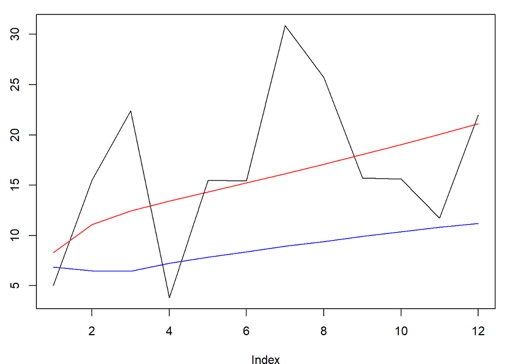

```r
# Plot
plot(sunspot1$x[889:900],type = "l")
lines(seq(1,12),f1$mean, col = "blue")
lines(seq(1,12), s1.fit12$f, col = 'red')
```

```r
# model 2
# ARIMA(2,1)
s2.fit12 = fore.arma.wge(sunspot2$x, phi = ss2.est.y$phi, theta = ss2.est.y$theta, n.ahead = 12, limits = FALSE, lastn = TRUE)
```

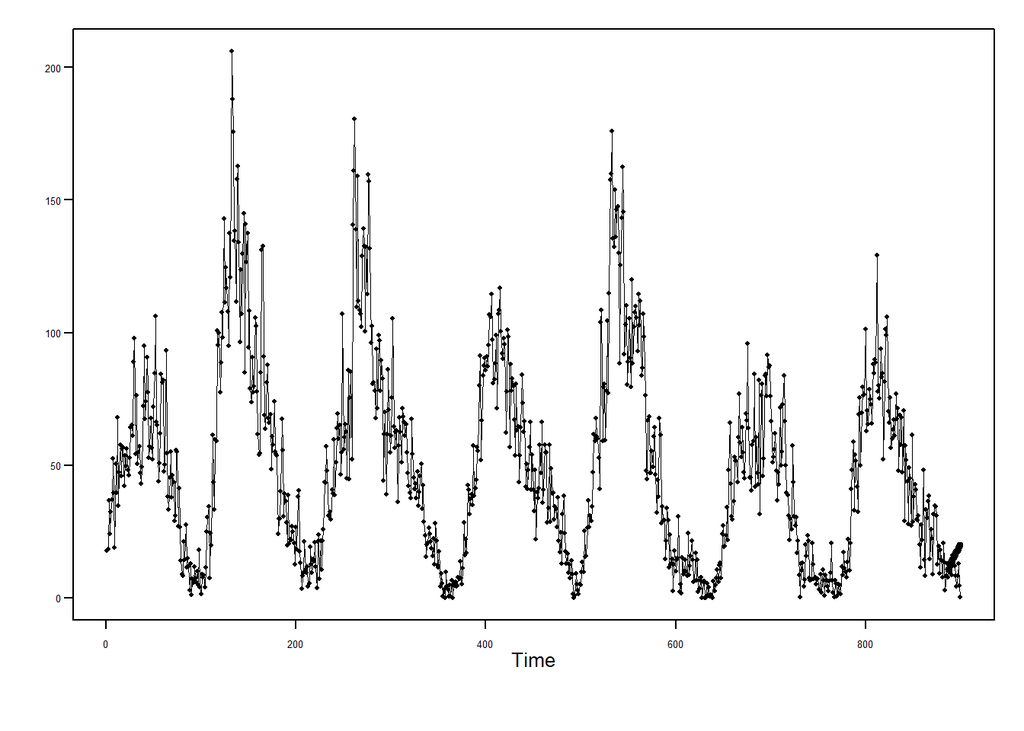

```r
# ASE
mean((sunspot2$x[781:900] - s2.fit12$f)^2)
```

```
## [1] 1693.43
```

```r
# RNN
rnns2 = ts(sunspot2$x[1:888])
rnns2.fit = mlp(rnns2)
f2 = forecast(rnns2.fit, h = 12)

#ASE
mean((sunspot2$x[889:900]-f2$mean)^2)
```

```
## [1] 42.23435
```

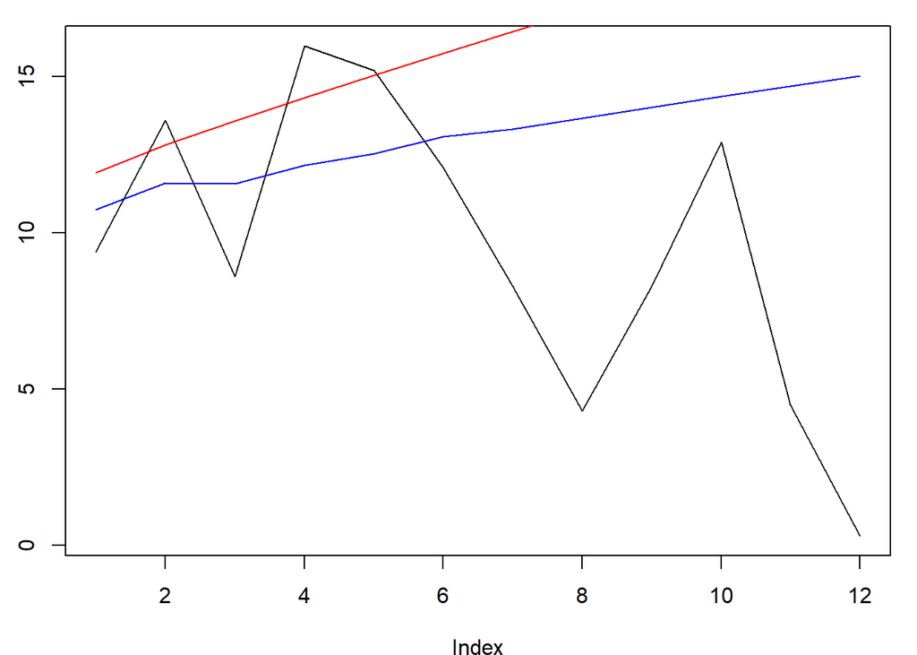

```r
# Plot
plot(sunspot2$x[889:900],type = "l")
lines(seq(1,12),f2$mean, col = "blue")
lines(seq(1,12), s2.fit12$f, col = 'red')
```

```r
# model 3
# ARIMA(9,8)
s3.fit12 = fore.arma.wge(sunspot3$x, phi = ss3.est.y$phi, theta = ss3.est.y$theta, n.ahead = 12, limits = FALSE, lastn = TRUE)
```

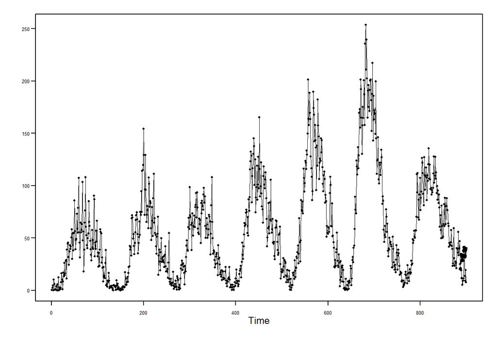

```r
# ASE
mean((sunspot3$x[781:900] - s3.fit12$f)^2)
```

```
## [1] 2341.278
```

```r
# RNN
rnns3 = ts(sunspot3$x[1:888])
rnns3.fit = mlp(rnns3)
f3 = forecast(rnns3.fit, h = 12)

#ASE
mean((sunspot3$x[889:900]-f3$mean)^2)
```

```
## [1] 322.4323
```

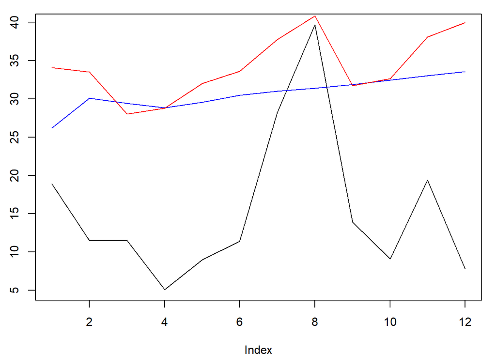

```r
# Plot
plot(sunspot3$x[889:900],type = "l")
lines(seq(1,12),f3$mean, col = "blue")
lines(seq(1,12), s3.fit12$f, col = 'red')
```

**4. Clearly describe why you chose the stationary or non-stationary model you chose above.**

The document to turn in here will be a knit pdf or html of an RMD (with the code visible.) Try and keep your output to a reasonable length but do provide useful comments (as usual) to your code and written explanations where appropriate. Be clear but terse. Part of the grade is on your results and part of your grade is how clear and efficient you are able to communicate your analysis. To be ultra-secure, please submit this to 2DS and email it to me as well.  
Great job this semester! I will see you at immersion and / or at graduation! Whamo!